# **Project 2**, APS1070 Fall 2023

**Anomaly Detection Algorithm using Gaussian Mixture Model**

**Deadline: OCT 27, 11 PM**

**Academic Integrity**

This project is individual - it is to be completed on your own. If you have questions, please post your query in the APS1070 Piazza Q&A forums (the answer might be useful to others!).

Do not share your code with others, or post your work online. Do not submit code that you have not written yourself. Students suspected of plagiarism on a project, midterm or exam will be referred to the department for formal discipline for breaches of the Student Code of Conduct.

Please fill out the following:

- Name: Declan Bracken
- Student Number: 1006251324

### How to submit **(HTML + IPYNB)**

1. Download your notebook: `File -> Download .ipynb`
2. Click on the Files icon on the far left menu of Colab
3. Select & upload your `.ipynb` file you just downloaded, and then obtain its path (right click) (you might need to hit the Refresh button before your file shows up)
1. execute the following in a Colab cell:

   ```
   %%shell
   jupyter nbconvert --to html /PATH/TO/YOUR/NOTEBOOKFILE.ipynb
   ```

2. An HTML version of your notebook will appear in the files, so you can download it.
3. Submit **both** `HTML` and `IPYNB` files on Quercus for grading.

Ref: https://stackoverflow.com/a/64487858

## **Part 1: Getting started [1.5 Marks]**

We are going to work with a [credit card fraud detection](https://www.kaggle.com/datasets/mlg-ulb/creditcardfraud) dataset, consisting of transactions made by credit cards in September 2013 by European cardholders. The dataset contains only numerical input variables (`V1`, `V2`, … `V28`) which are the principal components obtained with PCA transformation (PCA will the introduced later in this course), due to confidentiality issues. The only features which have not been transformed with PCA are `Time` (seconds elapsed between each transaction and the first transaction in the dataset) and `Amount` (transaction Amount).\ This dataset contains 30 key features, which are not directly interpretable but contain meaningful information about the dataset. Load the dataset in CSV file using Pandas. The dataset is called `creditcard.csv`. Print out the first few columns of the dataset.

- How many rows are there? **284807** **[0.1]**
- Which column contains the targets? **column 31** **[0.1]**
- What is the meaning of target values? **Whether the transaction is fraudulent** **[0.2]**

```python
pip install wget
```

```
  Preparing metadata (setup.py) ... done
```

```python
import wget

wget.download('https://raw.githubusercontent.com/Sabaae/Dataset/master/creditcard.csv')
```

```
'creditcard.csv'
```

```python
import pandas as pd
import numpy as np
import matplotlib.pyplot as plt
import seaborn as sns
from sklearn.model_selection import train_test_split
from sklearn.preprocessing import StandardScaler
```

```python
### YOUR CODE HERE ###
df = pd.read_csv('creditcard.csv')
```

```python
#print first few columns
print(df.head())
print(df.iloc[:, :3])
```

```
   Time        V1        V2        V3        V4        V5        V6        V7  \
0   0.0 -1.359807 -0.072781  2.536347  1.378155 -0.338321  0.462388  0.239599
1   0.0  1.191857  0.266151  0.166480  0.448154  0.060018 -0.082361 -0.078803
2   1.0 -1.358354 -1.340163  1.773209  0.379780 -0.503198  1.800499  0.791461
3   1.0 -0.966272 -0.185226  1.792993 -0.863291 -0.010309  1.247203  0.237609
4   2.0 -1.158233  0.877737  1.548718  0.403034 -0.407193  0.095921  0.592941

         V8        V9  ...       V21       V22       V23       V24       V25  \
0  0.098698  0.363787  ... -0.018307  0.277838 -0.110474  0.066928  0.128539
1  0.085102 -0.255425  ... -0.225775 -0.638672  0.101288 -0.339846  0.167170
2  0.247676 -1.514654  ...  0.247998  0.771679  0.909412 -0.689281 -0.327642
3  0.377436 -1.387024  ... -0.108300  0.005274 -0.190321 -1.175575  0.647376
4 -0.270533  0.817739  ... -0.009431  0.798278 -0.137458  0.141267 -0.206010

        V26       V27       V28  Amount  Class
```

[output cut: 21 more lines]

It's important to know how many examples we have for each class when we work with a new dataset.

- What is the percentage of entries in the dataset for each class? 99.83% is 0 and 0.17% is 1 **[0.1]**
- Is this data considered balanced or unbalanced? Why is this the case? Heavily Unbalanced **[0.1]**
- Why is balance/imbalance important? How might this class ditribution affect a KNN classifier for example, which we explored in Project 1? Inbalance can skew the bias of the model that we train. Since nearly all the data has an output 0, if we just trained a model to output 0, it would be 99.83% accurate!! If we used a knn classifier, it may be very hard for it to classify correctly, and it'd be difficult to find the optimized value for k.**[0.5]**
- What metrics should we use to evaluate a model in such cases? Precision, Accuracy, F1 Score. **[0.2]**

```python
### YOUR CODE HERE ###
#percent of examples in class 0:
value_counts = df['Class'].value_counts()
print(value_counts)
print(value_counts[0]/(value_counts[0]+value_counts[1]))
print(value_counts[1]/(value_counts[0]+value_counts[1]))
```

```
0    284315
1       492
Name: Class, dtype: int64
0.9982725143693799
0.001727485630620034
```

Next, split the dataset into a training (70%), validation (15%) and testing set (15%). Set the random state to 0. **[0.2]**

Make sure to separate out the column corresponding to the targets.

```python
### Split the data  ###
from sklearn.model_selection import train_test_split

X_train, X_val, X_test, y_train, y_val, y_test = 0, 0, 0, 0, 0, 0
from sklearn.model_selection import train_test_split

# Split DataFrame into ratios:
total_size = len(df)
val_size = int(0.15 * total_size)
test_size = int(0.15 * total_size)
train_size = int(0.7 * total_size)

# Separate the target column from the DataFrame
X = df.iloc[:, :-1]  # Input features
y = df.iloc[:, -1]   # Target labels

# Split the data into a temporary training set and a test set
X_train, X_test, y_train, y_test = train_test_split(X, y, test_size=test_size, random_state=0)

# Split the temporary training set into an actual training set and a validation set
X_train, X_val, y_train, y_val = train_test_split(X_train, y_train, test_size=val_size/ (val_size + train_size), random_state=0)

print("Training Set Size:", len(X_train))
print("Validation Set Size:", len(X_val))
print("Test Set Size:", len(X_test))
```

```
Training Set Size: 199364
Validation Set Size: 42722
Test Set Size: 42721
```

Now, let's take a look at the difference in distribution for all variables between non-fraudulent and fraudulent credit card transactions:

```
Time
V1
V2
V3
V4
V5
V6
V7
V8
V9
V10
V11
V12
V13
V14
V15
V16
V17
V18
V19
V20
V21
V22
V23
V24
V25
V26
V27
V28
Amount
```

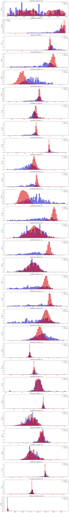

```python
import matplotlib.gridspec as gridspec
features=[f for f in df.columns if not 'Class' in f] #get features
nplots=np.size(features)
plt.figure(figsize=(15,4*nplots))
gs = gridspec.GridSpec(nplots,1)
for i, feat in enumerate(features):
    print(feat)
    ax = plt.subplot(gs[i])
    sns.histplot(X_train[feat][y_train==1], stat="density", kde=True, color="blue", bins=50)
    sns.histplot(X_train[feat][y_train==0], stat="density", kde=True, color="red", bins=50)
    ax.legend(['fraud', 'not-fraud'],loc='best')
    ax.set_xlabel('')
    ax.set_title('Distribution of feature: ' + feat)
```

Explain how these graphs could provide meaningful information about anomaly detection using a gaussian model. **[0.5]** These graphs help by giving us an intuitive and quantiative understanding about the differences in feature distribution between fraudulent and non-fraudulent transactions. It can help with detecting anomalies, or outliers, by analyzing which graphs have distinctive and well-seperated distributions. This also helps with feature extraction or selection, as I can look at each feature independantly and make a note of how seperated the distributions are between fradulent and non-fraudulent interactions. Additionaly, by analyzing these graphs I can choose appropriate thresholds based off variance and mean.

## **Part 2: Single feature model with one Gaussian distribution: [2.5 Marks]**

We'll start by making a prediction using **a single feature of our dataset at a time**.

Please note that we **only use `V` features** in our model.

**a. Fitting regardless of class:**

1. Fit a single Gaussian distribution on a single feature of **the full training dataset** (both classes) using `sklearn.mixture.GaussianMixture` when `n_components=1`.
2. Compute AUC (Area under the ROC Curve) based on `sklearn.mixture.GaussianMixture.score_samples` on both the full training set and validation set (including both classes).
3. Repeat the above steps for each of the features and present your findings in a table.
4. Find the best 3 features to distinguish fraud transactions from not-fraud transactions based on the AUC of the validation set. **[0.2]**
5. Make a prediction based on a model's scores: If the `score_samples` is lower than a threshold, we consider that transaction as a fraud. Find an optimal threshold that maximizes the F1 Score of the validation set for each of those 3 features separately. (Do not check every possible value for threshold, come up with a faster way!) Compute F1 score using `sklearn.metrics.f1_score`. **[0.5]**
6. Report the complexity of your method (Big O notation) for determining the optimal threshold.**[0.5]**

**b. Fitting based on class:**

1. Pick 3 features that had the best AUC in Part 2a.
2. Compute AUC and F1 score when you fit a Gaussian **only on not-fraud transactions** (instead of all the transactions).
3. Compare your results from parts 2a and 2b (AUC and F1 score) in a table. **[0.8]**
4. Are these results different or similar? Why?**[0.5]**

```python
### YOUR CODE HERE ###
### Part A:
from sklearn.mixture import GaussianMixture
import numpy as np
from sklearn.metrics import roc_auc_score

# Create an empty DataFrame to store the results
results = pd.DataFrame(columns=['Feature', 'Training AUC', 'Validation AUC'])
feature_names = X_train.columns

# Loop through all features
for feature_name in feature_names:
    # Extract the single feature data
    X_train_feature = X_train[[feature_name]].values
    X_val_feature = X_val[[feature_name]].values

    #create and fit a GaussianMixture model
    gmm = GaussianMixture(n_components=1)
    gmm.fit(X_train_feature)

    #calculate the NEGATIVE loglikelihood scores for both training and validation sets
    train_log_likelihood = -gmm.score_samples(X_train_feature)
    val_log_likelihood = -gmm.score_samples(X_val_feature)
    train_auc = roc_auc_score(y_train, train_log_likelihood)
    val_auc = roc_auc_score(y_val, val_log_likelihood)

    results = results.append({'Feature': feature_name, 'Training AUC': train_auc, 'Validation AUC': val_auc}, ignore_index=True)

print(results)
```

[output not shown]

[output cut: 20 more lines]

```
   Feature  Training AUC  Validation AUC
0     Time      0.510858        0.493492
1       V1      0.706621        0.721311
2       V2      0.842431        0.871587
3       V3      0.866022        0.915482
4       V4      0.889510        0.898720
5       V5      0.765528        0.790696
6       V6      0.739408        0.692421
7       V7      0.857009        0.907704
8       V8      0.775450        0.811463
9       V9      0.801466        0.812350
10     V10      0.909448        0.927298
11     V11      0.892799        0.939563
12     V12      0.909069        0.950517
13     V13      0.565471        0.576120
```

[output cut: 16 more lines]